# Topic 5 - CART - lab

MSDA - MSDA7003 Machine Learning

KT Wong

Faculty of Social Sciences, HKU

2024-11-08

The materials in this topic are drawn from Lantz (2023) and James et al. (2023)

# Tutorial lab

- You will practice decision trees on two datasets
  - identifying risky bank loans - classification tree
  - Boston housing data - regression tree
- we will use the `rpart` package to build a decision tree
- use the `rpart.plot` package to visualize the tree
- we will also use (some part of) **tidymodels** package to help us with the model specification and model evaluation

## Decision Trees Example - identify risky bank loans

### Motivation

- The global financial crisis of 2007-2008 highlighted the importance of transparency and rigor in banking practices
- As the availability of credit was limited
  - banks tightened their lending systems
  - they turned to machine learning to more accurately identify risky loans
- Decision trees are widely used in the banking industry due to
  - their high accuracy and ability to formulate a statistical model in plain language
- Since governments in many countries carefully monitor the fairness of lending practices
  - executives must be able to explain why one applicant was rejected for a loan while another was approved
  - This information is also useful for customers hoping to determine why their credit rating is unsatisfactory

## Decision Trees Example - identify risky bank loans

### Step 1 - Motivation and dataset

- Idea
  - credit model is to identify factors that are linked to a higher risk of loan default
  - data on *past bank loans* as well as *information about the loan applicants* that would have been available at the time of credit application
- use the dataset containing information on loans obtained from a credit agency in Germany prepared by Hans Hofmann of the University of Hamburg

## Decision Trees Example - identify risky bank loans

Step 2 - explore and prepare the data

- let us import the data
- the dataset contains 1000 rows and 17 columns
- the target variable is `default`, which indicates whether the loan was repaid or defaulted
- the remaining columns contain information about the loan applicants

```r
library(tidyverse)

credit<- read_csv("https://raw.githubusercontent.com/kwan-MSDA/MSDA7003/main/credit.csv")

credit<- credit %>%
  mutate_if(is.character, as.factor)

str(credit)
```

```
tibble [1,000 × 17] (S3: tbl_df/tbl/data.frame)
 $ checking_balance    : Factor w/ 4 levels "< 0 DM","> 200 DM",..: 1 3 4 1 1 4 4 3 4 3 ...
 $ months_loan_duration: num [1:1000] 6 48 12 42 24 36 24 36 12 30 ...
 $ credit_history      : Factor w/ 5 levels "critical","good",..: 1 2 1 2 4 2 2 2 2 1 ...
 $ purpose             : Factor w/ 6 levels "business","car",..: 5 5 4 5 2 4 5 2 5 2 ...
 $ amount              : num [1:1000] 1169 5951 2096 7882 4870 ...
 $ savings_balance     : Factor w/ 5 levels "< 100 DM","> 1000 DM",..: 5 1 1 1 1 5 4 1 2 1 ...
 $ employment_duration : Factor w/ 5 levels "< 1 year","> 7 years",..: 2 3 4 4 3 3 2 3 4 5 ...
 $ percent_of_income   : num [1:1000] 4 2 2 2 3 2 3 2 2 4 ...
 $ years_at_residence  : num [1:1000] 4 2 3 4 4 4 4 2 4 2 ...
 $ age                 : num [1:1000] 67 22 49 45 53 35 53 35 61 28 ...
 $ other_credit        : Factor w/ 3 levels "bank","none",..: 2 2 2 2 2 2 2 2 2 2 ...
 $ housing             : Factor w/ 3 levels "other","own",..: 2 2 2 1 1 1 2 3 2 2 ...
 $ existing_loans_count: num [1:1000] 2 1 1 1 2 1 1 1 1 2 ...
 $ job                 : Factor w/ 4 levels "management","skilled",..: 2 2 4 2 2 4 2 1 4 1 ...
 $ dependents          : num [1:1000] 1 1 2 2 2 2 1 1 1 1 ...
 $ phone               : Factor w/ 2 levels "no","yes": 2 1 1 1 1 2 1 2 1 1 ...
 $ default             : Factor w/ 2 levels "no","yes": 1 2 1 1 2 1 1 1 1 2 ...
```

## Decision Trees Example - identify risky bank loans

### Explore the data

```r
library(knitr)
library(kableExtra)

kable(head(credit, n=10), format="html") %>%
  kable_styling(bootstrap_options = c("striped", "hover", "condensed", "responsive"))
```

| checking_balance | months_loan_duration | credit_history | purpose | amount | savings_balance | employment_duration | percent_of_income | years_at_residence | age | other_credit | housing | existing_loans_count | job | dependents | phone | default |
| --- | --- | --- | --- | --- | --- | --- | --- | --- | --- | --- | --- | --- | --- | --- | --- | --- |
| < 0 DM | 6 | critical | furniture/appliances | 1169 | unknown | > 7 years | 4 | 4 | 67 | none | own | 2 | skilled | 1 | yes | no |
| 1 - 200 DM | 48 | good | furniture/appliances | 5951 | < 100 DM | 1 - 4 years | 2 | 2 | 22 | none | own | 1 | skilled | 1 | no | yes |
| unknown | 12 | critical | education | 2096 | < 100 DM | 4 - 7 years | 2 | 3 | 49 | none | own | 1 | unskilled | 2 | no | no |
| < 0 DM | 42 | good | furniture/appliances | 7882 | < 100 DM | 4 - 7 years | 2 | 4 | 45 | none | other | 1 | skilled | 2 | no | no |
| < 0 DM | 24 | poor | car | 4870 | < 100 DM | 1 - 4 years | 3 | 4 | 53 | none | other | 2 | skilled | 2 | no | yes |
| unknown | 36 | good | education | 9055 | unknown | 1 - 4 years | 2 | 4 | 35 | none | other | 1 | unskilled | 2 | yes | no |
| unknown | 24 | good | furniture/appliances | 2835 | 500 - 1000 DM | > 7 years | 3 | 4 | 53 | none | own | 1 | skilled | 1 | no | no |
| 1 - 200 DM | 36 | good | car | 6948 | < 100 DM | 1 - 4 years | 2 | 2 | 35 | none | rent | 1 | management | 1 | yes | no |
| unknown | 12 | good | furniture/appliances | 3059 | > 1000 DM | 4 - 7 years | 2 | 4 | 61 | none | own | 1 | unskilled | 1 | no | no |
| 1 - 200 DM | 30 | critical | car | 5234 | < 100 DM | unemployed | 4 | 2 | 28 | none | own | 2 | management | 1 | no | yes |

## Decision Trees Example - identify risky bank loans

### Explore the data

- **checking account** and **saving accounts** could be predictors of loan default status

```r
table(credit$checking_balance)
```

```
    < 0 DM   > 200 DM 1 - 200 DM    unknown
       274         63        269        394
```

```r
table(credit$savings_balance)
```

```
     < 100 DM     > 1000 DM  100 - 500 DM 500 - 1000 DM       unknown
          603            48           103            63           183
```

- Have a summary statistics about the loan amount and duration

```r
summary(credit$months_loan_duration)
```

```
   Min. 1st Qu.  Median    Mean 3rd Qu.    Max.
    4.0    12.0    18.0    20.9    24.0    72.0
```

```r
summary(credit$amount)
```

```
   Min. 1st Qu.  Median    Mean 3rd Qu.    Max.
    250    1366    2320    3271    3972   18424
```

- How many loans were repaid and how many defaulted?

```r
table(credit$default)
```

```
 no yes
700 300
```

## Decision Trees Example - identify risky bank loans

### data preparation - create random training and test sets

- use 90 percent of the data for training and 10 percent for testing
- the credit dataset might not be randomly ordered

```r
set.seed(202411)
train_sample<- sample(1000, 900)
str(train_sample)
```

```
 int [1:900] 241 250 707 316 601 471 859 518 29 453 ...
```

```r
credit_train<-credit[train_sample,]
credit_test<- credit[-train_sample,]
```

```r
prop.table(table(credit_train$default))
```

```
       no       yes
0.7022222 0.2977778
```

```r
prop.table(table(credit_test$default))
```

```
  no  yes
0.68 0.32
```

## Decision Trees Example - identify risky bank loans

### Step 3 - train the model

```r
library(tidymodels)

tree_spec <- decision_tree() %>%
  set_engine("rpart") %>%
  set_mode("classification")

credit_model2<- tree_spec %>% fit(default~., data=credit_train)

credit_model2
```

```
parsnip model object

n= 900

node), split, n, loss, yval, (yprob)
      * denotes terminal node

  1) root 900 268 no (0.7022222 0.2977778)
    2) checking_balance=> 200 DM,unknown 414  52 no (0.8743961 0.1256039) *
    3) checking_balance=< 0 DM,1 - 200 DM 486 216 no (0.5555556 0.4444444)
      6) months_loan_duration< 22.5 278  98 no (0.6474820 0.3525180)
       12) credit_history=critical,good,poor 254  79 no (0.6889764 0.3110236)
         24) amount< 7491.5 247  73 no (0.7044534 0.2955466)
           48) months_loan_duration< 11.5 75  12 no (0.8400000 0.1600000) *
           49) months_loan_duration>=11.5 172  61 no (0.6453488 0.3546512)
             98) amount>=1298 116  30 no (0.7413793 0.2586207) *
             99) amount< 1298 56  25 yes (0.4464286 0.5535714)
              198) purpose=business,education,furniture/appliances 35  15 no (0.5714286 0.4285714)
                396) existing_loans_count>=1.5 8   1 no (0.8750000 0.1250000) *
                397) existing_loans_count< 1.5 27  13 yes (0.4814815 0.5185185)
                  794) age< 30 16   5 no (0.6875000 0.3125000) *
                  795) age>=30 11   2 yes (0.1818182 0.8181818) *
              199) purpose=car,renovations 21   5 yes (0.2380952 0.7619048) *
         25) amount>=7491.5 7   1 yes (0.1428571 0.8571429) *
       13) credit_history=perfect,very good 24   5 yes (0.2083333 0.7916667) *
      7) months_loan_duration>=22.5 208  90 yes (0.4326923 0.5673077)
       14) savings_balance=> 1000 DM,unknown 35  10 no (0.7142857 0.2857143) *
       15) savings_balance=< 100 DM,100 - 500 DM,500 - 1000 DM 173  65 yes (0.3757225 0.6242775)
         30) percent_of_income< 2.5 64  31 no (0.5156250 0.4843750)
           60) purpose=car,education 24   7 no (0.7083333 0.2916667) *
           61) purpose=business,car0,furniture/appliances,renovations 40  16 yes (0.4000000 0.6000000)
            122) phone=no 25  11 no (0.5600000 0.4400000)
              244) age>=26 16   5 no (0.6875000 0.3125000) *
              245) age< 26 9   3 yes (0.3333333 0.6666667) *
            123) phone=yes 15   2 yes (0.1333333 0.8666667) *
         31) percent_of_income>=2.5 109  32 yes (0.2935780 0.7064220) *
```

## Decision Trees Example - identify risky bank loans

### Decision tree output

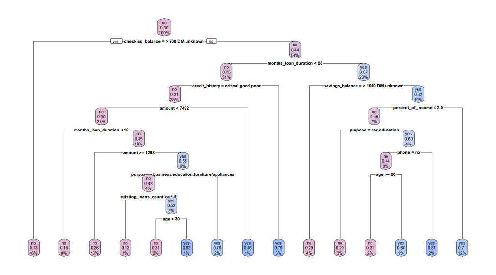

```r
library(rpart.plot)

# https://www.rdocumentation.org/packages/rpart.plot/versions/3.1.2/topics/rpart.plot

#pa_pal <- colorRampPalette(c("#A30664", "#E6B8D4", "#C6A1D1", "#A085CE", "#9FBBFC"))

pa_pal_2tone <- colorRampPalette(c("#DFBAD3", "#E6B8D4", "#BAD8F6", "#9FBBFC"))

credit_model2 %>%
  extract_fit_engine() %>%
  #rpart.plot(box.palette = pa_pal_2tone(6),, type=1, extra=104, cex=0.38)
  rpart.plot(
    roundint = FALSE,
    box.palette = pa_pal_2tone(6),
    tweak = 1.2
  )
```

## Decision Trees Example - identify risky bank loans

### Step 4 - Evaluate model performance

```r
augment(credit_model2, new_data=credit_test) %>%
  conf_mat(truth=default, estimate=.pred_class)
```

```
          Truth
Prediction no yes
       no  55  16
       yes 13  16
```

```r
augment(credit_model2, new_data=credit_test) %>%
  accuracy(truth=default, estimate=.pred_class)
```

```
# A tibble: 1 × 3
  .metric  .estimator .estimate
  <chr>    <chr>          <dbl>
1 accuracy binary          0.71
```

```r
library(vip)

vip(credit_model2, num_features = 10)
```

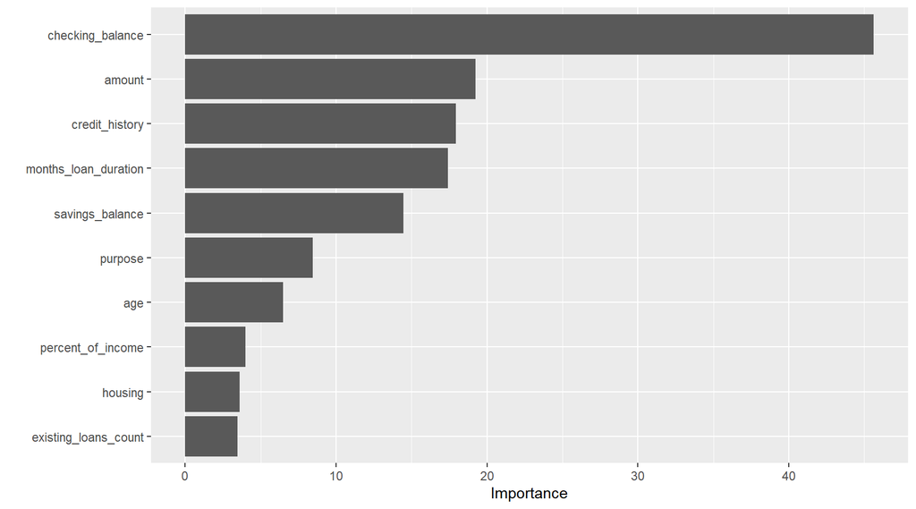

### Step 5 - improve model performance

- model’s error rate is likely to be too high to deploy it in a real-time credit scoring application
- Predicting loan defaults using only 900 training examples seems to be a challenging problem
- model performed especially poorly at identifying applicants who do default on their loans
- we will leave it later

# Boston housing data

It comes from a famous study on [environmental economics](https://www.law.berkeley.edu/files/Hedonic.PDF) by Harrison and Rubinfeld (1978)

## Load the data

```r
library(tidyverse)
library(tidymodels)
library(rpart.plot)
library(rpart)
library(vip)
library(caret)

boston<- read_csv("https://raw.githubusercontent.com/kwan-MSDA/MSDA7003/refs/heads/main/Boston.csv")

boston<- boston %>% select(-c(1))
```

- key variables
  - `medv` - median value of owner-occupied homes in $1000s
  - `crim` - per capita crime rate by town
  - `zn` - proportion of residential land zoned for lots over 25,000 sq.ft.
  - `indus` - proportion of non-retail business acres per town
  - `chas` - Charles River dummy variable (= 1 if tract bounds river; 0 otherwise)
  - `nox` - nitric oxides concentration (parts per 10 million)
  - `rm` - average number of rooms per dwelling
  - `age` - proportion of owner-occupied units built prior to 1940
  - `dis` - weighted distances to five Boston employment centres
  - `rad` - index of accessibility to radial highways
  - `tax` - full-value property-tax rate per $\$10,000$
  - `ptratio` - pupil-teacher ratio by town
  - `lstat` - % lower status of the population

## Specify the model

```r
reg_tree_spec<- decision_tree() %>%
  set_engine("rpart") %>%
  set_mode("regression")
```

## fit the model

```r
train<- boston %>% sample_frac(0.75)
test<- anti_join(boston, train)

reg_tree_fit<- reg_tree_spec %>% fit(medv~., data=train)

reg_tree_fit
```

```
parsnip model object

n= 380

node), split, n, deviance, yval
      * denotes terminal node

 1) root 380 33571.9100 22.55974
   2) rm< 6.941 325 13594.3700 19.87354
     4) lstat>=14.3 141  2563.3180 15.06028
       8) nox>=0.607 85  1047.1240 13.08235
        16) lstat>=19.645 45   352.2120 10.98000 *
        17) lstat< 19.645 40   272.2598 15.44750 *
       9) nox< 0.607 56   678.9112 18.06250 *
     5) lstat< 14.3 184  5261.2340 23.56196
      10) dis>=1.6009 177  2303.7500 23.01073
        20) rm< 6.543 135   959.8573 21.77111 *
        21) rm>=6.543 42   469.6390 26.99524 *
      11) dis< 1.6009 7  1543.8200 37.50000 *
   3) rm>=6.941 55  3775.1010 38.43273
     6) rm< 7.433 32   908.5297 33.40313 *
     7) rm>=7.433 23   930.8087 45.43043 *
```

## Visualize the tree

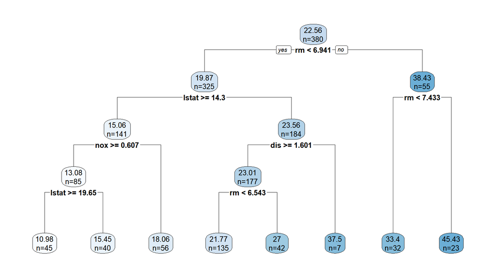

```r
reg_tree_fit %>%
  extract_fit_engine() %>%
  rpart.plot(extra=1, cex=0.8, digits=4)
```

## Evaluate the model

```r
augmented_data <- augment(reg_tree_fit, new_data = train)

# Compute RMSE
rmse_result <- yardstick::rmse(augmented_data, truth = medv, estimate = .pred)

# Print the RMSE result
print(rmse_result)
```

```
# A tibble: 1 × 3
  .metric .estimator .estimate
  <chr>   <chr>          <dbl>
1 rmse    standard        4.01
```

```r
augment(reg_tree_fit, new_data = test) %>% rmse(truth=medv, estimate=.pred)
```

```
# A tibble: 1 × 3
  .metric .estimator .estimate
  <chr>   <chr>          <dbl>
1 rmse    standard        4.55
```

```r
library(vip)

vip(reg_tree_fit, num_features = 10)
```

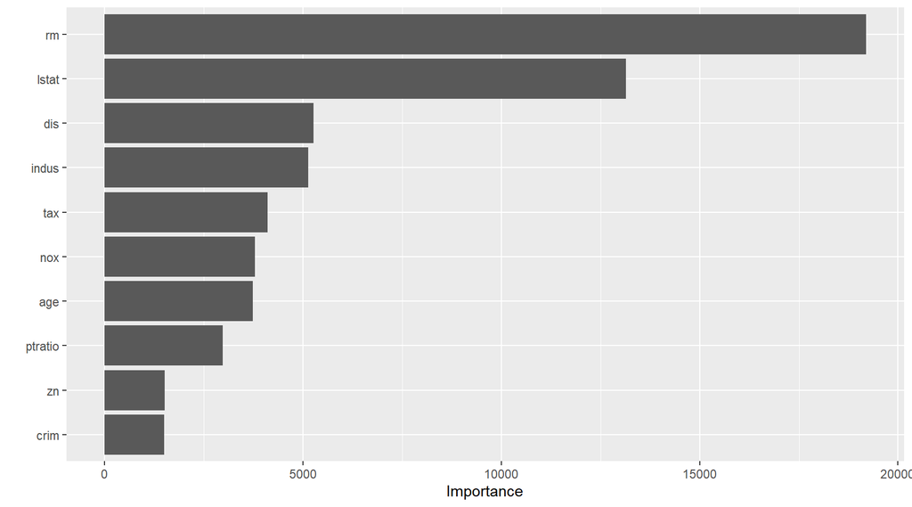

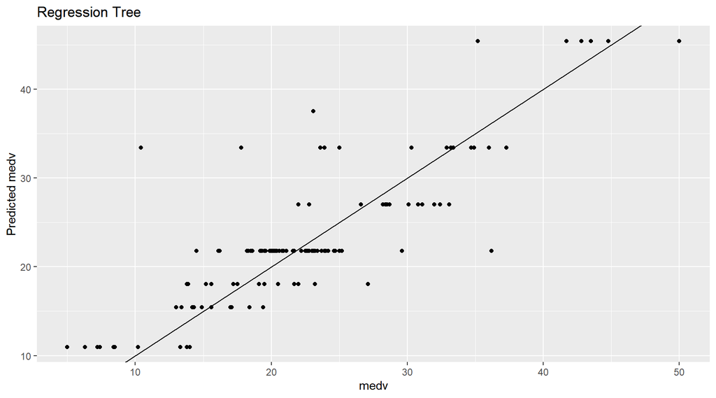

```r
augment(reg_tree_fit, new_data = test) %>%
  ggplot(aes(x=medv, y=.pred))+
  geom_point()+
  geom_abline()+
  labs(title="Regression Tree", x="medv", y="Predicted medv")
```

## Prune the tree

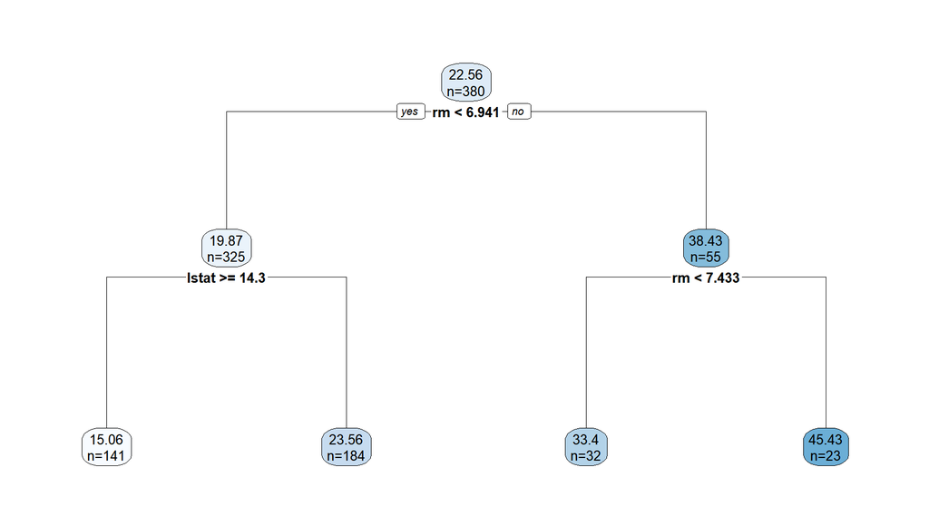

```r
prune<- reg_tree_fit %>%
  extract_fit_engine() %>%
  prune(cp=0.05)

prune %>% rpart.plot(extra=1, cex=0.8, digits=4)
```

```r
library(rpart)
library(yardstick)
library(dplyr)

# Prune the tree
# Fit the regression tree
reg_tree_fit <- rpart(medv ~ ., data = train)

prune <- prune(reg_tree_fit, cp = 0.05)

# Make predictions on the test data
predictions <- predict(prune, newdata = test)

# Calculate the RMSE
rmse <- rmse_vec(truth = test$medv, estimate = predictions)
print(rmse)
```

```
[1] 5.272321
```

## References

James, G., D. Witten, T. Hastie, and R. Tibshirani. 2023. *An Introduction to Statistical Learning with Applications in r*. Second edition. Springer.

Lantz, Brett. 2023. *Machine Learning with r : Learn Techniques for Building and Improving Machine Learning Models, from Data Preparation to Model Tuning, Evaluation, and Working with Big Data*. Fourth edition. Expert Insight. Birmingham, UK: Packt Publishing Limited.